# 01_read_data

## FPR vs TPR on the best model param

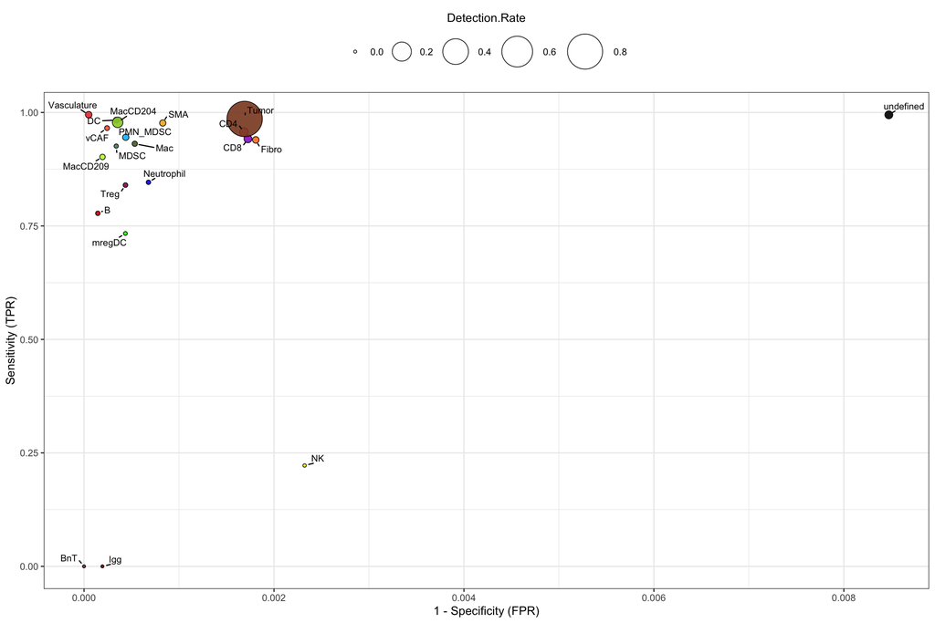

```r
# NOTE: графік TPR (Sensitivity) vs FPR (1-Specificity) по типах клітин; розмір точки = частота виявлення.
cv_perf <- data.frame(cm_cv$byClass) |>
  mutate(
    class = sub("Class: ", "", rownames(cm_cv$byClass)),
    fpr = 1 - Specificity
  )

ggplot(cv_perf) +
  geom_point(
    aes(
      x = fpr,
      y = Sensitivity,
      size = Detection.Rate,
      fill = class
    ),
    shape = 21,
    color = "black",
    alpha = 0.9
  ) +
  ggrepel::geom_text_repel(
    aes(
      x = fpr,
      y = Sensitivity,
      label = class
    ),
    size = 3,
    max.overlaps = Inf,
    min.segment.length = 0,
    box.padding = 0.3,
    point.padding = 0.2
  ) +
  scale_fill_manual(
    values = metadata(spe_27)$colour_vectors$cell_types,
    guide = "none"
  ) +
  scale_size(
    range = c(1, 15),
    guide = guide_legend(title.position = "top")
  ) +
  theme_bw() +
  theme(
    legend.position = "top",
    legend.title = element_text(hjust = 0.5)
  ) +
  ylab("Sensitivity (TPR)") +
  xlab("1 - Specificity (FPR)")
```

## check best model

extract evaluation dataframes

```r
# NOTE: збираємо evaluation_log усіх CV-моделей у один «довгий» data.frame (train/test mlogloss
# по ітераціях + параметри) для подальших таблиць і графіків.
#models <- readRDS(file.path(base_path, "ROut_rds_all", "models.rds"))

eval_data <- purrr::imap_dfr(models, function(model, model_id) {

  df <- model$evaluation_log

  best_iteration <- which.min(df$test_mlogloss_mean)
  best_mlogloss <- df$test_mlogloss_mean[best_iteration]

  df |>
    mutate(
      model_id = model_id,
      max_depth = model$params$max_depth,
      eta = model$params$eta,
      subsample = model$params$subsample,
      colsample_bytree = model$params$colsample_bytree,
      min_child_weight = model$params$min_child_weight,
      best_iteration = best_iteration,
      best_mlogloss = best_mlogloss,
      is_best_iteration = iter == best_iteration
    ) |>
    pivot_longer(
      cols = c(
        train_mlogloss_mean,
        train_mlogloss_std,
        test_mlogloss_mean,
        test_mlogloss_std
      ),
      names_to = c("Type", ".value"),
      names_pattern = "(train|test)_mlogloss_(mean|std)"
    ) |>
    dplyr::rename(
      mlogloss_mean = mean,
      mlogloss_std = std
    ) |>
    mutate(
      Type = stringr::str_to_title(Type),
      max_depth = as.factor(max_depth),
      eta = as.factor(eta),
      min_child_weight = as.factor(min_child_weight),
      params = paste(
        "depth", max_depth,
        "eta", eta,
        "sub", subsample,
        "col", colsample_bytree,
        "mcw", min_child_weight,
        sep = "_"
      )
    )
})

eval_data
```

```
## # A tibble: 3,930 × 14
##     iter model_id max_depth eta   subsample colsample_bytree min_child_weight
##    <int>    <int> <fct>     <fct>     <dbl>            <dbl> <fct>
##  1     1        1 3         0.05        0.8              0.8 1
##  2     1        1 3         0.05        0.8              0.8 1
##  3     2        1 3         0.05        0.8              0.8 1
##  4     2        1 3         0.05        0.8              0.8 1
##  5     3        1 3         0.05        0.8              0.8 1
##  6     3        1 3         0.05        0.8              0.8 1
##  7     4        1 3         0.05        0.8              0.8 1
##  8     4        1 3         0.05        0.8              0.8 1
##  9     5        1 3         0.05        0.8              0.8 1
## 10     5        1 3         0.05        0.8              0.8 1
## # ℹ 3,920 more rows
## # ℹ 7 more variables: best_iteration <int>, best_mlogloss <dbl>,
## #   is_best_iteration <lgl>, Type <chr>, mlogloss_mean <dbl>,
## #   mlogloss_std <dbl>, params <chr>
```

```r
# NOTE: підсумкова таблиця моделей за тестовим mlogloss на їхній найкращій ітерації (кращі зверху).
best_model_summary <- eval_data |>
  dplyr::filter(Type == "Test", is_best_iteration) |>
  arrange(best_mlogloss) |>
  select(
    model_id,
    max_depth,
    eta,
    subsample,
    colsample_bytree,
    min_child_weight,
    best_iteration,
    best_mlogloss,
    params
  )

best_model_summary
```

```
## # A tibble: 12 × 9
##    model_id max_depth eta   subsample colsample_bytree min_child_weight
##       <int> <fct>     <fct>     <dbl>            <dbl> <fct>
##  1        7 3         0.05        0.8              0.8 5
##  2       10 3         0.1         0.8              0.8 5
##  3        9 5         0.05        0.8              0.8 5
##  4        8 4         0.05        0.8              0.8 5
##  5       11 4         0.1         0.8              0.8 5
##  6       12 5         0.1         0.8              0.8 5
##  7        3 5         0.05        0.8              0.8 1
##  8        1 3         0.05        0.8              0.8 1
##  9        2 4         0.05        0.8              0.8 1
## 10        5 4         0.1         0.8              0.8 1
## 11        6 5         0.1         0.8              0.8 1
## 12        4 3         0.1         0.8              0.8 1
## # ℹ 3 more variables: best_iteration <int>, best_mlogloss <dbl>, params <chr>
```

## visualize model evaluation

```r
# NOTE: готуємо дані для теплової карти — мінімальний mlogloss по кожній комбінації гіперпараметрів
# окремо для Train і Test.
plot_heatmap_data <- eval_data |>
  dplyr::group_by(
    Type,
    eta,
    subsample,
    colsample_bytree,
    min_child_weight,
    max_depth
  ) |>
  dplyr::summarise(
    mlogloss = min(mlogloss_mean),
    .groups = "drop"
  ) |>
  dplyr::mutate(
    eta = as.factor(eta),
    subsample = as.factor(subsample),
    colsample_bytree = as.factor(colsample_bytree),
    min_child_weight = as.factor(min_child_weight),
    max_depth = as.factor(max_depth)
  )
```

```r
# NOTE: функція make_heatmap() будує теплову карту mlogloss (рядки=комбінації параметрів,
# стовпці=max_depth) з анотацією гіперпараметрів збоку; створюємо карти для Train і Test.
make_heatmap <- function(plot_data, cur_type, show_param_annotation = TRUE) {

  df <- plot_data |>
    dplyr::filter(Type == cur_type) |>
    arrange(
      eta,
      subsample,
      colsample_bytree,
      min_child_weight,
      max_depth
    ) |>
    pivot_wider(
      names_from = max_depth,
      values_from = mlogloss
    )

  depth_cols <- sort(unique(as.character(plot_data$max_depth)))

  mat <- df |>
    select(dplyr::all_of(depth_cols)) |>
    as.matrix()

  cur_col_fun <- if (cur_type == "Train") {
  circlize::colorRamp2(
    c(
      min(mat, na.rm = TRUE),
      median(mat, na.rm = TRUE),
      max(mat, na.rm = TRUE)
    ),
    c("#2166ac", "white", "#b2182b")
  )
} else {
  circlize::colorRamp2(
    c(
      min(mat, na.rm = TRUE),
      median(mat, na.rm = TRUE),
      max(mat, na.rm = TRUE)
    ),
    c("darkgreen", "white", "red")
  )
}

  anno_colors <- list(
  "learning rate" = c(
    "0.05" = "#1b9e77",
    "0.1"  = "#d95f02"
  ),
  "cell subsampl" = c(
    "0.8" = "#7570b3"
  ),
  "marker subsam" = c(
    "0.8" = "#66a61e"
  ),
  "min child w" = c(
    "1" = "#e7298a",
    "5" = "#e6ab02"
  )
)

  row_anno <- if (show_param_annotation) {
    ComplexHeatmap::rowAnnotation(
      "learning rate" = df$eta,
      "cell subsampl" = df$subsample,
      "marker subsam" = df$colsample_bytree,
      "min child w" = df$min_child_weight,
      col = anno_colors
    )
  } else {
    NULL
  }

  ComplexHeatmap::Heatmap(
    mat,
    name = paste0(cur_type, "\nmlogloss"),
    column_title = paste0(cur_type, " multiclass log-loss"),
    column_title_gp = grid::gpar(fontsize = 12, fontface = "bold"),
    col = cur_col_fun,
    left_annotation = row_anno,
    cluster_rows = FALSE,
    cluster_columns = FALSE,
    show_column_names = TRUE,
    column_names_gp = grid::gpar(fontsize = 10),
    show_row_names = FALSE,
    cell_fun = function(j, i, x, y, width, height, fill) {
      grid::grid.text(
        sprintf("%.3f", mat[i, j]),
        x,
        y,
        gp = grid::gpar(fontsize = 9)
      )
    }
  )
}

hm_train <- make_heatmap(plot_heatmap_data, "Train", show_param_annotation = TRUE)
hm_test  <- make_heatmap(plot_heatmap_data, "Test", show_param_annotation = FALSE)
```

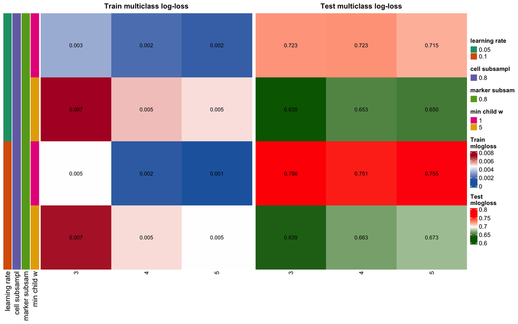

```r
# NOTE: показуємо теплові карти Train і Test поруч для порівняння (де перенавчання).
hm_train + hm_test
```

The test mlogloss indicates that max_depth = 3 gives the best balance between model complexity and generalization, while deeper trees tend to reduce train loss but increase test loss, suggesting overfitting.

The higher min_child_weight value performs better, indicating that a more conservative tree-splitting strategy is preferable for these data

```r
# NOTE: визначаємо єдину найкращу модель (один рядок) за тестовим mlogloss.
best_model_summary <- eval_data |>
  dplyr::filter(Type == "Test", is_best_iteration) |>
  arrange(best_mlogloss) |>
  dplyr::slice(1)

best_model_summary
```

```
## # A tibble: 1 × 14
##    iter model_id max_depth eta   subsample colsample_bytree min_child_weight
##   <int>    <int> <fct>     <fct>     <dbl>            <dbl> <fct>
## 1   181        7 3         0.05        0.8              0.8 5
## # ℹ 7 more variables: best_iteration <int>, best_mlogloss <dbl>,
## #   is_best_iteration <lgl>, Type <chr>, mlogloss_mean <dbl>,
## #   mlogloss_std <dbl>, params <chr>
```

```r
# NOTE: дістаємо назву параметрів, найкращу ітерацію і loss найкращої моделі для підпису на графіку.
best_param_name <- best_model_summary$params
best_iter <- best_model_summary$best_iteration
best_loss <- best_model_summary$best_mlogloss
```

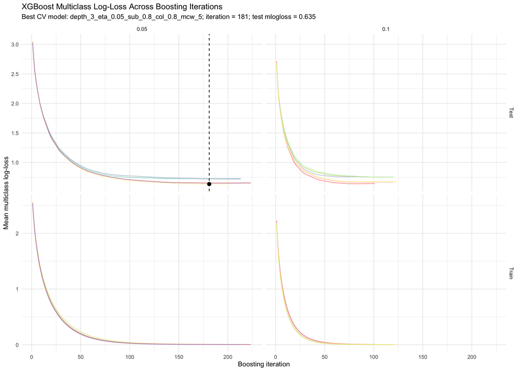

```r
# NOTE: криві mlogloss по ітераціях бустингу для всіх моделей (фасет Train/Test x eta),
# з позначкою обраної найкращої ітерації — видно перенавчання при глибших деревах.
ggplot(
  eval_data,
  aes(
    x = iter,
    y = mlogloss_mean,
    color = params,
    group = params
  )
) +
  geom_line(alpha = 0.75, linewidth = 0.6) +
  geom_vline(
    data = best_model_summary,
    aes(xintercept = best_iteration),
    inherit.aes = FALSE,
    linetype = "dashed",
    color = "black"
  ) +
  geom_point(
    data = best_model_summary,
    aes(
      x = best_iteration,
      y = best_mlogloss
    ),
    inherit.aes = FALSE,
    size = 3,
    color = "black"
  ) +
  facet_grid(rows = vars(Type), cols = vars(eta), scales = "free_y") +
  scale_color_brewer(palette = "Set3") +
  theme_minimal(base_size = 13) +
  theme(
    legend.position = "none",
    legend.title = element_blank()
  ) +
  labs(
    title = "XGBoost Multiclass Log-Loss Across Boosting Iterations",
    subtitle = paste0(
      "Best CV model: ",
      best_param_name,
      "; iteration = ", best_iter,
      "; test mlogloss = ", round(best_loss, 3)
    ),
    x = "Boosting iteration",
    y = "Mean multiclass log-loss"
  )
```

Columns separate the learning rate values: eta = 0.05 on the left and eta = 0.1 on the right. In both training and test panels, log-loss decreases as more boosting iterations are added. Training loss continues to approach zero, especially for more flexible models, while test loss decreases initially and then plateaus. This gap between train and test loss reflects expected overfitting as boosting continues

# final classifier

```r
# NOTE: навчаємо ФІНАЛЬНУ модель xgb.train на ВСІХ train-клітинах з найкращими параметрами та nrounds
# (CV використовувалась лише для вибору параметрів). Саме ця модель іде на тест і прогнози.
# Train the final XGBoost model on all training cells using the best CV parameters.
# CV is only used to select parameters; this model is the one used for held-out
# test evaluation and later prediction on unlabelled cells.
final_model <- xgboost::xgb.train(
  params = params_best,
  data = Xy,
  nrounds = best_nrounds,
  verbose = TRUE
)
```

save final model via saveRDS

```r
# NOTE: (закоментовано) збереження фінальної моделі у .rds; розкоментуй, щоб зберегти на диск.
# saveRDS(
#   final_model,
#   file = file.path(base_path, "classifier_xgboost.rds")
# )
```

```r
# NOTE: рахуємо важливість маркерів (xgb.importance за метрикою Gain) і беремо топ-20 для графіка.
# final_model <- readRDS(
#   file.path(base_path, "classifier_xgboost.rds")
# )

# Extract marker importance from the trained XGBoost model.
# Gain reflects how much each marker contributed to reducing the loss.
#xgb.importance(model = final_model,feature_names =c("SMA"))

var_imp <- xgboost::xgb.importance(
  feature_names = colnames(X),
  model = final_model
)

var_imp |>
  slice_max(Gain, n = 20)
```

```
##        Feature       Gain      Cover  Frequency
##         <char>      <num>      <num>      <num>
##  1:      CD209 0.07575074 0.05838209 0.05165807
##  2:      CD204 0.07502949 0.07203239 0.06691231
##  3:        CD3 0.07441356 0.10116654 0.09941046
##  4:       CD20 0.07332571 0.05160972 0.03839352
##  5:      CD66b 0.06240704 0.04668688 0.03662491
##  6:       CD31 0.05529139 0.03255984 0.02844510
##  7:      FOXP3 0.05134853 0.03336815 0.02770818
##  8:      Lamp3 0.05121077 0.03156918 0.02498158
##  9:      CD146 0.04646296 0.04053257 0.03264554
## 10:       MMP9 0.04257521 0.02260126 0.02365512
## 11:       Ecad 0.04207800 0.03999340 0.03596168
## 12:      CD11c 0.04204621 0.04449658 0.03492999
## 13:        CD7 0.04091303 0.03541879 0.03168755
## 14:       CD8a 0.03820846 0.04161869 0.03389831
## 15:        SMA 0.03348219 0.04069048 0.03235077
## 16:       CD45 0.03168087 0.04230498 0.04207811
## 17:      CD11b 0.02742082 0.03415980 0.02925571
## 18:       CD56 0.02624724 0.01739754 0.02365512
## 19: Podoplanin 0.02221450 0.03319819 0.03014001
## 20:       CD15 0.01031202 0.01366455 0.02041268
##        Feature       Gain      Cover  Frequency
##         <char>      <num>      <num>      <num>
```

```r
var_imp_top <- var_imp |>
  dplyr::slice_max(Gain, n = 20) |>
  dplyr::mutate(
    Feature = forcats::fct_reorder(Feature, Gain)
  )
```

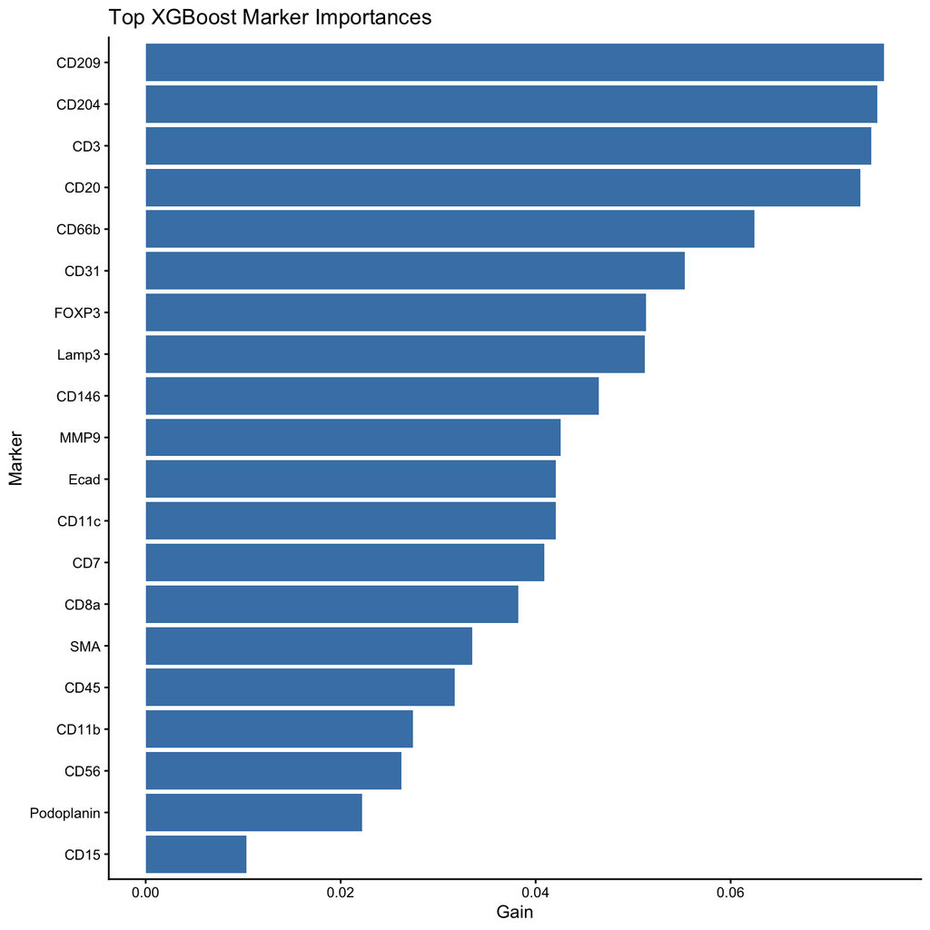

```r
# NOTE: стовпчиковий графік топ-20 найважливіших маркерів за Gain.
ggplot(var_imp_top, aes(x = Gain, y = Feature)) +
  geom_col(fill = "steelblue") +
  theme_classic() +
  labs(
    title = "Top XGBoost Marker Importances",
    x = "Gain",
    y = "Marker"
  )
```

Variable importance was assessed using XGBoost gain, which measures how much each marker contributes to reducing the model loss across tree splits. The most informative markers were CD3, CD204, CD209, CD20, Lamp3, CD31, FOXP3, CD66b, and CD146. These markers correspond well to the expected biology of the annotated cell types, including T cells, B cells, macrophage/DC populations, vasculature, neutrophil-like cells, and stromal compartments.

This is a useful sanity check: the model is not relying on strange markers; it is using biologically meaningful features.

# prepare test data

```r
# NOTE: готуємо held-out тестові дані — той самий набір маркерів, що і в навчанні, ті самі
# рівні label_mapping; будуємо X_test і Xy_test (xgb.DMatrix) лише для гейтованих тест-клітин.
test_sce$cell_id <- paste0(
  test_sce$sample_id,
  "_",
  test_sce$ObjectNumber
)

colnames(test_sce) <- test_sce$cell_id

# Labelled cells only for evaluation
test_eval_keep <- !is.na(test_sce$cell_labels) &
  test_sce$cell_labels != "unlabelled" &
  test_sce$cell_labels %in% label_mapping

# Use the same marker set as training
X_test <- t(assay(test_sce, "exprs")[marker_keep, test_eval_keep])

# Check that train and test feature columns match
stopifnot(identical(colnames(X), colnames(X_test)))

# Convert test labels using the training label mapping
y_test_true <- factor(
  test_sce$cell_labels[test_eval_keep],
  levels = label_mapping
)

y_test <- as.integer(y_test_true) - 1

stopifnot(!anyNA(y_test))

# Store labelled test data in XGBoost format
Xy_test <- xgboost::xgb.DMatrix(
  data = X_test,
  label = y_test
)

Xy_test
```

```
## xgb.DMatrix  dim: 6358 x 41  info: label  colnames: yes
```

## visualize predicted results

```r
# NOTE: прогноз фінальної моделі на тесті; xgb віддає плаский вектор ймовірностей, тому пробуємо
# обидва способи reshape у матрицю (клітини x класи) і перевіряємо, де ймовірності сумуються в 1.
raw_test_pred <- predict(final_model, newdata = Xy_test)

# Try both possible reshaping directions
test_prob_byrow <- matrix(
  raw_test_pred,
  ncol = num_classes,
  byrow = TRUE
)

test_prob_bycol <- matrix(
  raw_test_pred,
  ncol = num_classes,
  byrow = FALSE
)

# Check which one has probabilities summing to 1 per cell
mean(abs(rowSums(test_prob_byrow) - 1))
```

```
## [1] 1.712478
```

```r
mean(abs(rowSums(test_prob_bycol) - 1))
```

```
## [1] 3.182239e-08
```

```r
# NOTE: обираємо правильно зорієнтовану матрицю ймовірностей, перевіряємо розміри та підписуємо
# рядки (cell_id) і стовпці (типи клітин з label_mapping).
if (
  mean(abs(rowSums(test_prob_byrow) - 1)) <
  mean(abs(rowSums(test_prob_bycol) - 1))
) {
  test_prob <- test_prob_byrow
} else {
  test_prob <- test_prob_bycol
}

stopifnot(nrow(test_prob) == sum(test_eval_keep))
stopifnot(nrow(test_prob) == nrow(X_test))
stopifnot(ncol(test_prob) == num_classes)
stopifnot(mean(abs(rowSums(test_prob) - 1)) < 1e-6)

rownames(test_prob) <- colnames(test_sce)[test_eval_keep]
colnames(test_prob) <- label_mapping
```

```r
# NOTE: з ймовірностей беремо передбачений клас (max.col), зіставляємо з істинними мітками тесту
# і будуємо confusion matrix на held-out наборі.
test_pred <- factor(
  label_mapping[max.col(test_prob, ties.method = "first")],
  levels = label_mapping
)

test_idx <- match(
  rownames(test_prob),
  colnames(test_sce)
)

stopifnot(!anyNA(test_idx))

test_true <- factor(
  test_sce$cell_labels[test_idx],
  levels = label_mapping
)

stopifnot(
  length(test_pred) == length(test_true),
  !anyNA(test_true)
)

cm_test <- caret::confusionMatrix(
  data = test_pred,
  reference = test_true
)
```

```r
# NOTE: confusion matrix на тесті (рядки=передбачено, стовпці=істина).
cm_test$table
```

```
##              Reference
## Prediction       B  BnT  CD4  CD8   DC Fibro  Igg MDSC  Mac MacCD204 MacCD209
##   B              7    0    0    0    0     0    0    0    0        0        0
##   BnT            0    2    0    0    0     0    0    0    0        0        0
##   CD4            0    1  121    0    0     0    0    0    0        0        0
##   CD8            0    0    2  112    0     0    0    0    0        0        0
##   DC             0    0    0    0    6     0    0    0    0        0        0
##   Fibro          1    0    0    0    0    67    0    0    0        0        0
##   Igg            0    0    0    0    0     0    2    0    0        0        0
##   MDSC           0    0    0    0    0     0    0    5    0        0        0
##   Mac            0    0    0    0    0     0    0    0   13        1        0
##   MacCD204       0    0    0    0    0     0    0    0    0      158        0
##   MacCD209       0    0    0    0    0     0    0    0    0        0       21
##   NK             0    0    0    1    0     0    0    0    0        0        0
##   Neutrophil     0    0    0    0    0     1    0    2    0        0        0
##   PMN_MDSC       0    0    0    0    0     0    0    0    0        0        0
##   SMA            0    0    0    0    0     8    0    0    0        0        0
##   Treg           0    0    0    0    0     2    0    0    0        0        0
##   Tumor          0    0    1    0    1     0    0    0    0        0        0
##   Vasculature    0    0    0    0    0     0    0    0    0        0        0
##   mregDC         0    0    0    0    0     0    0    0    0        0        0
##   undefined      0    0    0    0    0     0    0    0    0        0        0
##   vCAF           0    0    0    0    0     0    0    0    0        0        0
##              Reference
## Prediction      NK Neutrophil PMN_MDSC  SMA Treg Tumor Vasculature mregDC
##   B              0          0        0    0    0     0           0      0
##   BnT            0          0        0    0    0     0           0      0
##   CD4            0          0        0    0    0     0           0      0
##   CD8            0          0        0    0    0     0           0      0
##   DC             0          0        0    0    0     0           0      0
##   Fibro          0          0        0    0    0     1           0      0
##   Igg            0          0        0    0    0     0           0      0
##   MDSC           0          0        0    0    0     1           0      0
##   Mac            0          0        0    0    0     0           0      0
##   MacCD204       0          0        0    0    0     0           0      0
##   MacCD209       0          0        0    0    0     0           0      0
##   NK             3          0        0    0    0     0           0      0
##   Neutrophil     0         11        0    0    0     0           0      0
##   PMN_MDSC       0          0       17    0    0     0           0      0
##   SMA            0          0        0   45    0     0           0      0
```

[output cut: 14 more lines]

```
##   Igg                 0    0
##   MDSC                0    0
##   Mac                 0    0
##   MacCD204            0    0
##   MacCD209            0    0
##   NK                  0    0
##   Neutrophil          0    0
##   PMN_MDSC            0    0
##   SMA                 0   16
##   Treg                0    0
##   Tumor               0    0
##   Vasculature         0    0
##   mregDC              0    0
##   undefined          70    0
##   vCAF                0   61
```

```r
# NOTE: загальні метрики моделі на held-out тесті (Accuracy, Kappa тощо).
cm_test$overall
```

```
##       Accuracy          Kappa  AccuracyLower  AccuracyUpper   AccuracyNull
##   9.938660e-01   9.747581e-01   9.916241e-01   9.956346e-01   8.689840e-01
## AccuracyPValue  McnemarPValue
##  1.507597e-318            NaN
```

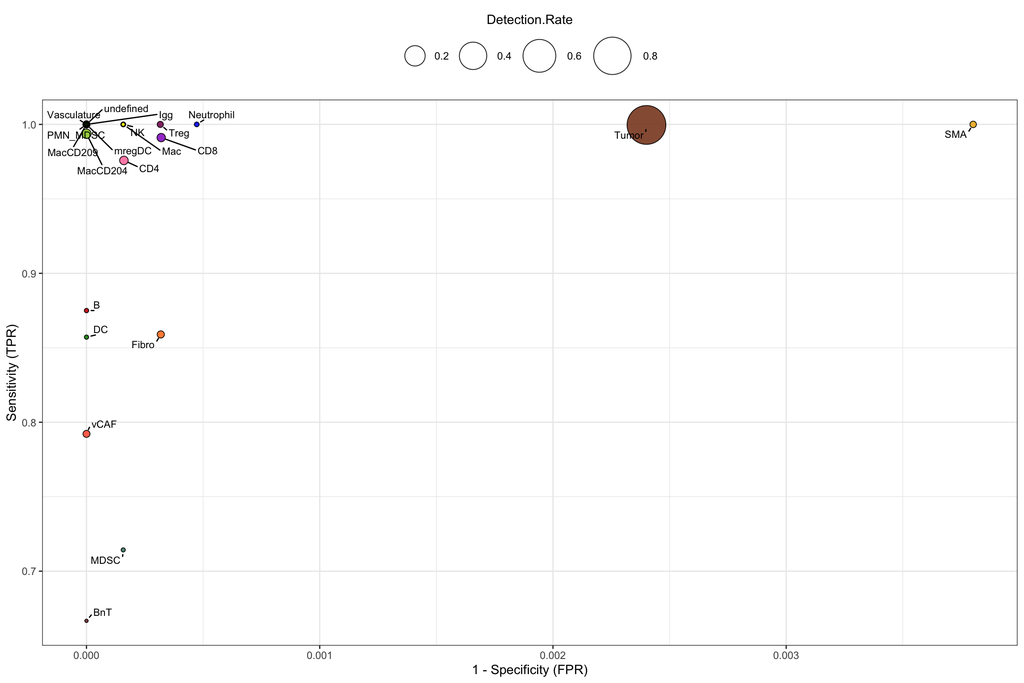

```r
# NOTE: фінальний графік продуктивності на тесті — TPR (Sensitivity) vs FPR (1-Specificity)
# по кожному типу клітин; розмір точки = частота виявлення.
# Per-cell-type performance plot.
test_perf <- data.frame(cm_test$byClass) |>
  dplyr::mutate(
    class = sub("Class: ", "", rownames(cm_test$byClass)),
    fpr = 1 - Specificity
  )

ggplot(test_perf) +
  geom_point(
    aes(
      x = fpr,
      y = Sensitivity,
      size = Detection.Rate,
      fill = class
    ),
    shape = 21,
    color = "black",
    alpha = 0.9
  ) +
  ggrepel::geom_text_repel(
    aes(
      x = fpr,
      y = Sensitivity,
      label = class
    ),
    size = 3,
    max.overlaps = Inf,
    min.segment.length = 0,
    box.padding = 0.3,
    point.padding = 0.2
  ) +
  scale_fill_manual(
    values = metadata(spe_27)$colour_vectors$cell_types,
    guide = "none"
  ) +
  scale_size(
    range = c(1, 15),
    guide = guide_legend(title.position = "top")
  ) +
  theme_bw() +
  theme(
    legend.position = "top",
    legend.title = element_text(hjust = 0.5)
  ) +
  ylab("Sensitivity (TPR)") +
  xlab("1 - Specificity (FPR)")
```

# Підсумок прогону

## Main_training_results (головний результат)

**Головний результат роботи моделі — це CV accuracy / Kappa** (out-of-fold, усереднено по 5 згрупованих фолдах — чесна оцінка узагальнення). Test accuracy наведена лише довідково: вона **завищена** дисбалансом класів (NIR тесту ≈ 0.869, бо ~87% тестових клітин — Tumor). Деталі по кожному типу — у `byClass` та confusion matrix нижче.

```r
Main_training_results <- data.frame(
  metric = c(
    "CV accuracy (out-of-fold) — ГОЛОВНЕ",
    "CV Kappa — ГОЛОВНЕ",
    "macro Sensitivity (CV, серед. по типах)",
    "macro Precision (CV, серед. по типах)",
    "No-information rate (test)",
    "Test accuracy (довідково, завищена)",
    "Test Kappa",
    "К-сть класів",
    "Train клітин",
    "Test клітин"
  ),
  value = c(
    round(cm_cv$overall["Accuracy"], 4),
    round(cm_cv$overall["Kappa"], 4),
    round(mean(cm_cv$byClass[, "Sensitivity"], na.rm = TRUE), 4),
    round(mean(cm_cv$byClass[, "Pos Pred Value"], na.rm = TRUE), 4),
    round(cm_test$overall["AccuracyNull"], 4),
    round(cm_test$overall["Accuracy"], 4),
    round(cm_test$overall["Kappa"], 4),
    num_classes,
    ncol(train_sce),
    ncol(test_sce)
  ),
  row.names = NULL
)
Main_training_results
```

```
##                                     metric      value
## 1      CV accuracy (out-of-fold) — ГОЛОВНЕ     0.9788
## 2                       CV Kappa — ГОЛОВНЕ     0.9335
## 3  macro Sensitivity (CV, серед. по типах)     0.8020
## 4    macro Precision (CV, серед. по типах)     0.7871
## 5               No-information rate (test)     0.8690
## 6      Test accuracy (довідково, завищена)     0.9939
## 7                               Test Kappa     0.9748
## 8                             К-сть класів    21.0000
## 9                             Train клітин 20678.0000
## 10                             Test клітин  6358.0000
```

```r
write.csv(Main_training_results, "Main_training_results.csv", row.names = FALSE)
```

## 1. Train/test поділ (+ збереження на диск)

Поділ зроблено **на рівні знімків** (`sample_id`) — усі клітини знімка йдуть в один бік, тож витоку між train і test немає.

**Параметри `split_test_rows()`, що використані:**

```r
data.frame(
  parameter = c("default_test_frac", "rare_test_frac", "rare_labels",
                "rare_weight", "n_restarts", "seed"),
  value = c(
    as.character(split_params$default_test_frac),
    as.character(split_params$rare_test_frac),
    paste(split_params$rare_labels, collapse = ", "),
    as.character(split_params$rare_weight),
    as.character(split_params$n_restarts),
    as.character(split_params$seed)),
  meaning = c(
    "частка клітин у тест для частих типів",
    "частка клітин у тест для рідкісних типів",
    "які типи вважаються рідкісними (балансуються окремо)",
    "наскільки сильніше тягнути рідкісні типи до цілі",
    "к-сть випадкових перезапусків оптимізатора",
    "сід відтворюваності"),
  row.names = NULL
)
```

```
##           parameter                         value
## 1 default_test_frac                           0.2
## 2    rare_test_frac                           0.2
## 3       rare_labels B, BnT, MDSC, Igg, mregDC, NK
## 4       rare_weight                            20
## 5        n_restarts                          1000
## 6              seed                            42
##                                                meaning
## 1                частка клітин у тест для частих типів
## 2             частка клітин у тест для рідкісних типів
## 3 які типи вважаються рідкісними (балансуються окремо)
## 4     наскільки сильніше тягнути рідкісні типи до цілі
## 5           к-сть випадкових перезапусків оптимізатора
## 6                                  сід відтворюваності
```

```r
cat("TRAIN знімки (", length(res$train_rownames), "):\n", sep = "")
```

```
## TRAIN знімки (20):
```

```r
print(res$train_rownames)
```

```
##  [1] "10123868-USL-VAR-TIS-01-IMC-02_001" "10123869-USL-VAR-TIS-01-IMC-02_003"
##  [3] "10123873-USL-VAR-TIS-01-IMC-02_003" "10123874-USL-VAR-TIS-01-IMC-02_003"
##  [5] "10123875-USL-VAR-TIS-01-IMC-02_001" "10123876-USL-VAR-TIS-01-IMC-02_002"
##  [7] "10123878-USL-VAR-TIS-01-IMC-02_003" "10123879-USL-VAR-TIS-01-IMC-02_003"
##  [9] "10123881-USL-VAR-TIS-01-IMC-02_001" "10123882-USL-VAR-TIS-01-IMC-02_003"
## [11] "10123884-USL-VAR-TIS-01-IMC-02_002" "10123885-USL-VAR-TIS-01-IMC-02_003"
## [13] "10123886-USL-VAR-TIS-01-IMC-02_002" "10123887-USL-VAR-TIS-01-IMC-02_001"
## [15] "10123887-USL-VAR-TIS-01-IMC-02_002" "10123888-USL-VAR-TIS-01-IMC-02_002"
## [17] "10123892-USL-VAR-TIS-01-IMC-02_001" "10123892-USL-VAR-TIS-01-IMC-02_002"
## [19] "10123893-USL-VAR-TIS-01-IMC-02_002" "10123894-USL-VAR-TIS-01-IMC-02_002"
```

```r
cat("\nTEST знімки (", length(res$test_rownames), "):\n", sep = "")
```

```
##
## TEST знімки (7):
```

```r
print(res$test_rownames)
```

```
## [1] "10123871-USL-VAR-TIS-01-IMC-02_001" "10123874-USL-VAR-TIS-01-IMC-02_002"
## [3] "10123876-USL-VAR-TIS-01-IMC-02_003" "10123880-USL-VAR-TIS-01-IMC-02_002"
## [5] "10123895-USL-VAR-TIS-01-IMC-02_003" "10123897-USL-VAR-TIS-01-IMC-02_002"
## [7] "10123899-USL-VAR-TIS-01-IMC-02_003"
```

```r
split_stats
```

```
##     cell_label train_n test_n
## 1            B      45      8
## 2          BnT      32      3
## 3          CD4     488    124
## 4          CD8     396    113
## 5           DC     119      7
## 6        Fibro     215     78
## 7          Igg      11      2
## 8         MDSC      27      7
## 9          Mac      87     13
## 10    MacCD204     919    159
## 11    MacCD209     102     21
## 12          NK       9      3
## 13  Neutrophil      39     11
## 14    PMN_MDSC     183     17
## 15         SMA     172     45
## 16        Treg      50     37
## 17       Tumor   17130   5525
## 18 Vasculature     201     35
## 19      mregDC      15      3
## 20   undefined     380     70
## 21        vCAF      58     77
```

```r
res$summary
```

```
##          label total test_count train_count target_test_frac achieved_test_frac
## 1            B    53          8          45              0.2              0.151
## 2          BnT    35          3          32              0.2              0.086
## 3          CD4   612        124         488              0.2              0.203
## 4          CD8   509        113         396              0.2              0.222
## 5           DC   126          7         119              0.2              0.056
## 6        Fibro   293         78         215              0.2              0.266
## 7          Igg    13          2          11              0.2              0.154
## 8         MDSC    34          7          27              0.2              0.206
## 9          Mac   100         13          87              0.2              0.130
## 10    MacCD204  1078        159         919              0.2              0.147
## 11    MacCD209   123         21         102              0.2              0.171
## 12          NK    12          3           9              0.2              0.250
## 13  Neutrophil    50         11          39              0.2              0.220
## 14    PMN_MDSC   200         17         183              0.2              0.085
```

[output cut: 29 more lines]

```r
rare_balance
```

```
## # A tibble: 10 × 4
##    split cell_labels total_cells n_samples
##    <chr> <chr>             <int>     <int>
##  1 test  BnT                   3         1
##  2 test  Igg                   2         2
##  3 test  MDSC                  7         3
##  4 test  mregDC                3         2
##  5 test  vCAF                 77         5
##  6 train BnT                  32         2
##  7 train Igg                  11         3
##  8 train MDSC                 27         8
##  9 train mregDC               15         5
## 10 train vCAF                 58        11
```

```r
write.csv(split_stats, "split_stats.csv", row.names = FALSE)

split_images <- rbind(
  data.frame(sample_id = res$train_rownames, split = "train"),
  data.frame(sample_id = res$test_rownames,  split = "test")
)
write.csv(split_images, "split_images.csv", row.names = FALSE)

saveRDS(
  list(
    train_cell_ids = colnames(train_sce),
    test_cell_ids  = colnames(test_sce),
    train_images   = res$train_rownames,
    test_images    = res$test_rownames,
    summary        = res$summary,
    split_stats    = split_stats
  ),
  "split.rds"
)

cat("\nЗбережено: split_stats.csv, split_images.csv, split.rds\n")
```

```
##
## Збережено: split_stats.csv, split_images.csv, split.rds
```

## 2. Параметри моделі XGBoost

```r
data.frame(
  parameter = c("max_depth", "eta (learning rate)", "subsample", "colsample_bytree",
                "min_child_weight", "nrounds", "objective", "eval_metric", "num_class"),
  value = as.character(c(
    params_best$max_depth, params_best$eta, params_best$subsample,
    params_best$colsample_bytree, params_best$min_child_weight, best_nrounds,
    params_best$objective, params_best$eval_metric, params_best$num_class)),
  meaning = c(
    "глибина дерева (складність)", "внесок кожного дерева", "частка клітин на дерево",
    "частка маркерів на дерево", "мін. вага в листі (консервативність)",
    "к-сть дерев (раундів)", "багатоклас. класифікація", "метрика (log-loss)",
    "к-сть класів"),
  row.names = NULL
)
```

```
##             parameter          value                              meaning
## 1           max_depth              3          глибина дерева (складність)
## 2 eta (learning rate)           0.05                внесок кожного дерева
## 3           subsample            0.8              частка клітин на дерево
## 4    colsample_bytree            0.8            частка маркерів на дерево
## 5    min_child_weight              5 мін. вага в листі (консервативність)
## 6             nrounds            181                к-сть дерев (раундів)
## 7           objective multi:softprob             багатоклас. класифікація
## 8         eval_metric       mlogloss                   метрика (log-loss)
## 9           num_class             21                         к-сть класів
```

## 3. Очистка даних — так, робилась

**(а) Консолідація міток:**

```r
consolidation_stats
```

```
##                            category     n
## 1       total_unique_gated_cell_ids 80687
## 2   same_label_duplicates_collapsed    49
## 3                 single_label_kept 80564
## 4 tumor_plus_other_renamed_to_other    68
## 5        non_tumor_doublets_removed    55
```

**(б) Біологічні правила очистки** (к-сть зачеплених клітин):

```r
.lab <- spe_27[, !is.na(spe_27$cell_labels) & spe_27$cell_labels != "unlabelled"]
.e   <- assay(.lab, "exprs")

data.frame(
  rule = c("Igg з IgG<1 — ВИДАЛЕНО",
           "NK з CD7<0.5 — ВИДАЛЕНО",
           "mregDC з panCK>0.5 | Ecad>0.8 — ПЕРЕМІЧЕНО на Tumor",
           "1 порожній знімок — ВИДАЛЕНО (28 -> 27 знімків)"),
  n_cells = c(
    sum(.lab$cell_labels == "Igg" & .e["IgG", ] < 1),
    sum(.lab$cell_labels == "NK"  & .e["CD7", ] < 0.5),
    sum(.lab$cell_labels == "mregDC" & (.e["panCK", ] > 0.5 | .e["Ecad", ] > 0.8)),
    NA_integer_
  ),
  row.names = NULL
)
```

```
##                                                  rule n_cells
## 1                              Igg з IgG<1 — ВИДАЛЕНО       0
## 2                             NK з CD7<0.5 — ВИДАЛЕНО       0
## 3 mregDC з panCK>0.5 | Ecad>0.8 — ПЕРЕМІЧЕНО на Tumor       4
## 4     1 порожній знімок — ВИДАЛЕНО (28 -> 27 знімків)      NA
```

## 4. Метрики на held-out тесті

**Per-class sensitivity / precision** (рідкісні типи слабші):

```r
round(as.data.frame(cm_test$byClass)[, c("Sensitivity", "Specificity",
                                         "Pos Pred Value", "Detection Rate")], 3)
```

```
##                    Sensitivity Specificity Pos Pred Value Detection Rate
## Class: B                 0.875       1.000          1.000          0.001
## Class: BnT               0.667       1.000          1.000          0.000
## Class: CD4               0.976       1.000          0.992          0.019
## Class: CD8               0.991       1.000          0.982          0.018
## Class: DC                0.857       1.000          1.000          0.001
## Class: Fibro             0.859       1.000          0.971          0.011
## Class: Igg               1.000       1.000          1.000          0.000
## Class: MDSC              0.714       1.000          0.833          0.001
## Class: Mac               1.000       1.000          0.929          0.002
## Class: MacCD204          0.994       1.000          1.000          0.025
## Class: MacCD209          1.000       1.000          1.000          0.003
## Class: NK                1.000       1.000          0.750          0.000
## Class: Neutrophil        1.000       1.000          0.786          0.002
## Class: PMN_MDSC          1.000       1.000          1.000          0.003
## Class: SMA               1.000       0.996          0.652          0.007
## Class: Treg              1.000       1.000          0.949          0.006
## Class: Tumor             1.000       0.998          1.000          0.869
## Class: Vasculature       1.000       1.000          1.000          0.006
## Class: mregDC            1.000       1.000          1.000          0.000
## Class: undefined         1.000       1.000          1.000          0.011
## Class: vCAF              0.792       1.000          1.000          0.010
```

**Повна confusion matrix** (рядки = predicted, стовпці = reference/істина):

```r
cm_mat <- as.data.frame.matrix(cm_test$table)
cm_mat
```

```
##             B BnT CD4 CD8 DC Fibro Igg MDSC Mac MacCD204 MacCD209 NK Neutrophil
## B           7   0   0   0  0     0   0    0   0        0        0  0          0
## BnT         0   2   0   0  0     0   0    0   0        0        0  0          0
## CD4         0   1 121   0  0     0   0    0   0        0        0  0          0
## CD8         0   0   2 112  0     0   0    0   0        0        0  0          0
## DC          0   0   0   0  6     0   0    0   0        0        0  0          0
## Fibro       1   0   0   0  0    67   0    0   0        0        0  0          0
## Igg         0   0   0   0  0     0   2    0   0        0        0  0          0
## MDSC        0   0   0   0  0     0   0    5   0        0        0  0          0
## Mac         0   0   0   0  0     0   0    0  13        1        0  0          0
## MacCD204    0   0   0   0  0     0   0    0   0      158        0  0          0
## MacCD209    0   0   0   0  0     0   0    0   0        0       21  0          0
## NK          0   0   0   1  0     0   0    0   0        0        0  3          0
## Neutrophil  0   0   0   0  0     1   0    2   0        0        0  0         11
## PMN_MDSC    0   0   0   0  0     0   0    0   0        0        0  0          0
## SMA         0   0   0   0  0     8   0    0   0        0        0  0          0
## Treg        0   0   0   0  0     2   0    0   0        0        0  0          0
## Tumor       0   0   1   0  1     0   0    0   0        0        0  0          0
## Vasculature 0   0   0   0  0     0   0    0   0        0        0  0          0
## mregDC      0   0   0   0  0     0   0    0   0        0        0  0          0
## undefined   0   0   0   0  0     0   0    0   0        0        0  0          0
## vCAF        0   0   0   0  0     0   0    0   0        0        0  0          0
##             PMN_MDSC SMA Treg Tumor Vasculature mregDC undefined vCAF
## B                  0   0    0     0           0      0         0    0
## BnT                0   0    0     0           0      0         0    0
## CD4                0   0    0     0           0      0         0    0
## CD8                0   0    0     0           0      0         0    0
## DC                 0   0    0     0           0      0         0    0
## Fibro              0   0    0     1           0      0         0    0
## Igg                0   0    0     0           0      0         0    0
## MDSC               0   0    0     1           0      0         0    0
## Mac                0   0    0     0           0      0         0    0
## MacCD204           0   0    0     0           0      0         0    0
## MacCD209           0   0    0     0           0      0         0    0
## NK                 0   0    0     0           0      0         0    0
## Neutrophil         0   0    0     0           0      0         0    0
## PMN_MDSC          17   0    0     0           0      0         0    0
## SMA                0  45    0     0           0      0         0   16
## Treg               0   0   37     0           0      0         0    0
## Tumor              0   0    0  5523           0      0         0    0
## Vasculature        0   0    0     0          35      0         0    0
## mregDC             0   0    0     0           0      3         0    0
## undefined          0   0    0     0           0      0        70    0
## vCAF               0   0    0     0           0      0         0   61
```

```r
write.csv(cm_mat, "confusion_matrix_test.csv")
```

**Матриця прогнозів по клітинах** (predicted) — зберігається у `test_predictions.csv`:

```r
pred_df <- data.frame(
  cell_id   = rownames(test_prob),
  true      = as.character(test_true),
  predicted = as.character(test_pred),
  prob_max  = round(apply(test_prob, 1, max), 3),
  correct   = as.character(test_true) == as.character(test_pred),
  row.names = NULL
)
write.csv(pred_df, "test_predictions.csv", row.names = FALSE)

cat("Розподіл ПЕРЕДБАЧЕНИХ класів на тесті:\n")
```

```
## Розподіл ПЕРЕДБАЧЕНИХ класів на тесті:
```

```r
print(table(predicted = test_pred))
```

```
## predicted
##           B         BnT         CD4         CD8          DC       Fibro
##           7           2         122         114           6          69
##         Igg        MDSC         Mac    MacCD204    MacCD209          NK
##           2           6          14         158          21           4
##  Neutrophil    PMN_MDSC         SMA        Treg       Tumor Vasculature
##          14          17          69          39        5525          35
##      mregDC   undefined        vCAF
##           3          70          61
```

```r
cat("\nПерші 20 прогнозів:\n")
```

```
##
## Перші 20 прогнозів:
```

```r
head(pred_df, 20)
```

```
##                                   cell_id  true predicted prob_max correct
## 1  10123871-USL-VAR-TIS-01-IMC-02_001_135    NK        NK    0.863    TRUE
## 2  10123871-USL-VAR-TIS-01-IMC-02_001_189   Igg       Igg    0.635    TRUE
## 3  10123871-USL-VAR-TIS-01-IMC-02_001_552    NK        NK    0.975    TRUE
## 4  10123871-USL-VAR-TIS-01-IMC-02_001_658    NK        NK    0.842    TRUE
## 5    10123874-USL-VAR-TIS-01-IMC-02_002_2 Tumor     Tumor    0.996    TRUE
## 6    10123874-USL-VAR-TIS-01-IMC-02_002_7 Tumor     Tumor    0.997    TRUE
## 7   10123874-USL-VAR-TIS-01-IMC-02_002_10 Tumor     Tumor    0.998    TRUE
## 8   10123874-USL-VAR-TIS-01-IMC-02_002_13 Tumor     Tumor    0.998    TRUE
## 9   10123874-USL-VAR-TIS-01-IMC-02_002_16 Tumor     Tumor    0.998    TRUE
## 10  10123874-USL-VAR-TIS-01-IMC-02_002_18 Tumor     Tumor    0.996    TRUE
## 11  10123874-USL-VAR-TIS-01-IMC-02_002_20 Tumor     Tumor    0.998    TRUE
## 12  10123874-USL-VAR-TIS-01-IMC-02_002_23 Tumor     Tumor    0.997    TRUE
## 13  10123874-USL-VAR-TIS-01-IMC-02_002_27 Tumor     Tumor    0.972    TRUE
## 14  10123874-USL-VAR-TIS-01-IMC-02_002_28 Tumor     Tumor    0.997    TRUE
## 15  10123874-USL-VAR-TIS-01-IMC-02_002_31 Tumor     Tumor    0.998    TRUE
## 16  10123874-USL-VAR-TIS-01-IMC-02_002_32 Tumor     Tumor    0.902    TRUE
## 17  10123874-USL-VAR-TIS-01-IMC-02_002_38 Tumor     Tumor    0.993    TRUE
## 18  10123874-USL-VAR-TIS-01-IMC-02_002_39 Tumor     Tumor    0.997    TRUE
## 19  10123874-USL-VAR-TIS-01-IMC-02_002_40 Tumor     Tumor    0.998    TRUE
## 20  10123874-USL-VAR-TIS-01-IMC-02_002_41 Tumor     Tumor    0.996    TRUE
```

## 5. Що ще робилось (повний пайплайн)

1. **Read** — `read_steinbock()` будує SPE.
2. **Spillover-компенсація** (CATALYST) — `compCytof()`, `exprs = asinh(counts / cofactor)`.
3. **Імпорт ручних гейтів** → нормалізація міток → матч по `cell_id`.
4. **Консолідація** дублікатів/doublets.
5. **Очистка** — біологічні правила + видалення порожнього знімка.
6. **Train/test поділ** на рівні знімків (`split_test_rows`, `seed=42`).
7. **Ваги класів** (inverse-frequency; `undefined` ÷10, `Igg` ÷30).
8. **Підбір параметрів** — grid-search `xgb.cv` (12 комбінацій), згруповані фолди.
9. **Фінальна модель** `xgb.train` + оцінка на held-out тесті.

> ⚠️ **Головне:** результат роботи моделі = **CV accuracy ≈ 0.979 / Kappa ≈ 0.934** (точні числа — у блоці `Main_training_results` вище). Ще чесніший погляд — **macro-метрики** (серед. по типах): Sensitivity ≈ 0.80, Precision ≈ 0.79 — вони нижчі за загальну accuracy, бо рідкісні типи слабші. Test accuracy ≈ 0.994 — лише довідкова й завищена Tumor-дисбалансом (NIR ≈ 0.869).